# Bat Echolocation Project

Capstone project: BIDA 302

Author

**Rajwant Kaur**

Published

November 27, 2025

## Import libraries

```r
library(tidyverse)
library(tidymodels)
library(gt)
```

## Import data

```r
#Import raw data
species_data_raw <- read_csv("Bat_Call_Data.csv")
#cleaning and variable type definition
bat_data <- species_data_raw %>%
##rename columns
  rename(
    time_btw_calls = Time_Btw_Calls,
    call_duration = Duration,
    char_frequency = Frequency,
    char_slope = Slope
  ) %>%
  mutate(
    Species = as_factor(Species) #to a factor
  )

glimpse(bat_data)
```

```
Rows: 120
Columns: 6
$ Species        <fct> EPFU, EPFU, EPFU, EPFU, EPFU, EPFU, EPFU, EPFU, EPFU, E…
$ Filename       <chr> "B6212118.46#", "B7122143.02#", "B7122201.58#", "B71222…
$ time_btw_calls <dbl> 170, 218, 174, 275, 213, 145, 181, 130, 128, 146, 398, …
$ char_frequency <dbl> 26, 26, 27, 26, 26, 27, 25, 28, 29, 25, 26, 29, 28, 26,…
$ call_duration  <dbl> 6, 7, 5, 7, 5, 3, 3, 3, 4, 5, 7, 3, 4, 7, 6, 5, 5, 5, 5…
$ char_slope     <dbl> 32, 24, 23, 29, 38, 38, 48, 55, 28, 44, 22, 42, 42, 18,…
```

## Tidying and manipulation

```r
#find the columns with na values
cat("Count of Missing Values (NA) per column:\n")
```

```
Count of Missing Values (NA) per column:
```

```r
bat_data %>%
  summarise(across(everything(), ~ sum(is.na(.))))
```

```
# A tibble: 1 × 6
  Species Filename time_btw_calls char_frequency call_duration char_slope
    <int>    <int>          <int>          <int>         <int>      <int>
1       0        0              0              0             0          0
```

```r
##create the summary table
sp_summary_table <- bat_data %>%
  group_by(Species) %>%
  summarise(
    N = n(),
    ##calculate and round Mean and SD for all parameters
    Mean_Freq = round(mean(char_frequency, na.rm = TRUE), 2),
    SD_Freq = round(sd(char_frequency, na.rm = TRUE), 2),
    Mean_Duration = round(mean(call_duration, na.rm = TRUE), 2),
    SD_Duration = round(sd(call_duration, na.rm = TRUE), 2),
    Mean_Slope = round(mean(char_slope, na.rm = TRUE), 2),
    SD_Slope = round(sd(char_slope, na.rm = TRUE), 2),
    Mean_TimeBtw = round(mean(time_btw_calls, na.rm = TRUE), 2),
    SD_TimeBtw = round(sd(time_btw_calls, na.rm = TRUE), 2)
  )

#display
sp_summary_table
```

```
# A tibble: 4 × 10
  Species     N Mean_Freq SD_Freq Mean_Duration SD_Duration Mean_Slope SD_Slope
  <fct>   <int>     <dbl>   <dbl>         <dbl>       <dbl>      <dbl>    <dbl>
1 EPFU       30      27.1    1.14          4.63        1.4        36.5    12.7
2 LACI       30      19.1    1.88          5.83        1.26       15.1     9.62
3 MYLU       30      39.2    1.89          2           0.91       66.5    17.4
4 MYVO       30      37.6    1.59          2.03        0.61       97.0    34.9
# ℹ 2 more variables: Mean_TimeBtw <dbl>, SD_TimeBtw <dbl>
```

## Visualizations

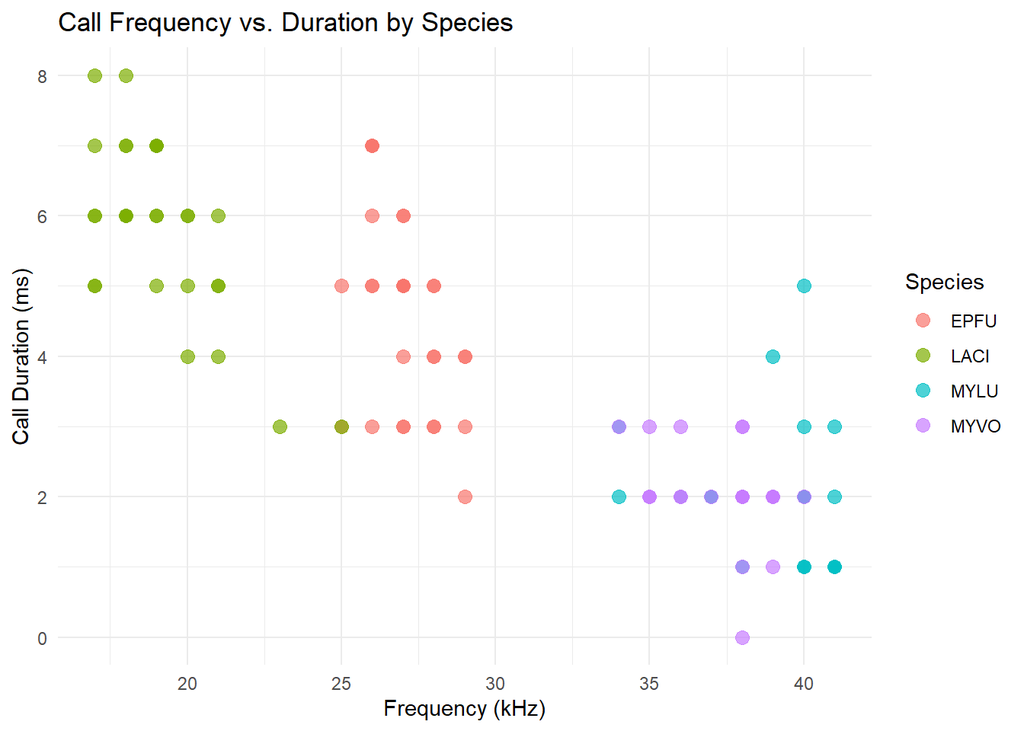

```r
#=============Plot 1: Call Frequency vs. Duration by Species================
ggplot(bat_data,
       aes(x = char_frequency, y = call_duration, color = Species)) +
  geom_point(alpha = 0.7, size = 3) +
  labs(
    title = "Call Frequency vs. Duration by Species",
    x = "Frequency (kHz)",
    y = "Call Duration (ms)"
  ) +
  theme_minimal()
```

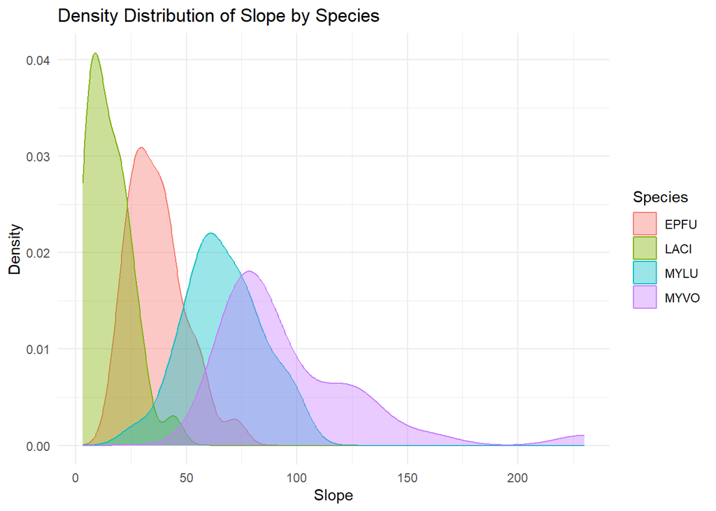

```r
#=========Plot 2: Density Distribution of Characteristic Slope by Species==========

ggplot(bat_data, aes(x = char_slope, fill = Species, color = Species)) +
  geom_density(alpha = 0.4) +
  labs(
    title = "Density Distribution of Slope by Species",
    x = "Slope",
    y = "Density",
    fill = "Species",
    color = "Species"
  ) +
  theme_minimal()
```

## Modelling: Random Forest

```r
##Import randomforest library
library(randomForest)
set.seed(123)

## 70% training data
train_index <- sample(
  1:nrow(bat_data),
  size = 0.7 * nrow(bat_data)
)
#split into training and testing
train_data <- bat_data[train_index, ]
test_data  <- bat_data[-train_index, ]

##fit the model to parameters
model <- randomForest(
  Species ~ call_duration + char_frequency + time_btw_calls + char_slope,
  data = train_data,
  ntree = 300,
  mtry = 2
)

#make predictions
predictions <- predict(model, newdata = test_data)

#accuracy
model_accuracy <- mean(predictions == test_data$Species)
model_accuracy
```

```
[1] 0.8888889
```

## 6. Conclusion

This capstone project confirmed that echolocation call parameters can effectively differentiate the four Vancouver Island bat species. The Random Forest classifier performed strongly, achieving an accuracy of 0.8889, indicating that the measured acoustic features provide substantial discriminatory power across species. The model’s performance supports the idea that call duration, characteristic frequency, time between calls, and slope capture meaningful biological differences in echolocation behaviour. These results highlight the potential for automated acoustic classification tools to support long-term bat monitoring and ecological research.

## Other Sources

**Statistical analysis of bat calls**

David W. Armitage and Holly K. Ober, A comparison of supervised learning techniques in the classification of bat echolocation calls, *Ecological Infomatics*, 2010, 5, 465:473.

Xing Chen, Jun Zhaob, Yan-hua Chen, Wei Zhoub, and Alice C.Hughes, [Automatic standardized processing and identification of tropical bat calls using deep learning approaches](https://www.sciencedirect.com/science/article/pii/S0006320719308961), *Biological Conservation*, January 2020, Vol.241, doi: 10.1016/j.biocon.2019.108269

Oisin MacAodha, Rory Gibb, Kate E. Barlow, et al., [Bat detective—Deep learning tools for bat acoustic signal detection](https://journals.plos.org/ploscompbiol/article?id=10.1371/journal.pcbi.1005995), *PLOS Computational Biology*, 2018-03-08, doi: 10.1371/journal.pcbi.1005995

Keisuke Masuda, Takanori Matsui, Dai Fukui, et al., [Bat species classification by echolocation call using a machine learning system](https://www.jstage.jst.go.jp/article/mammalianscience/57/1/57_19/_article), *Honyurui Kagaku (Mammalian Science)*, Volume 57 (2017) Issue 1. doi: 10.11238/mammalianscience.57.19

Peter Ommundsen,Cori Lausen, Laura Matthias, [First Acoustic Records of the Brazilian Free-Tailed Bat (Tadarida brasiliensis) In British Columbia](https://www.researchgate.net/publication/319424456_First_Acoustic_Records_of_the_Brazilian_Free-Tailed_Bat_Tadarida_brasiliensis_In_British_Columbia), September 2017, *Northwestern Naturalist*, 98(2):132-136, DOI: 10.1898/NWN16-24.1

Veronica Zamora-Gutierrez, Celia Lopez-Gonzalez, M. Cristina MacSwiney Gonzalez, et al., [Acoustic identification of Mexican bats based on taxonomic and ecological constraints on call design](https://besjournals.onlinelibrary.wiley.com/doi/pdf/10.1111/2041-210X.12556), *Methods in Ecology and Evolution* 2016, 7, 1082–1091. doi: 10.1111/2041-210X.12556

**Other bat communication**

Jason Daley, [Researchers “Translate” Bat Talk. Turns Out, They Argue—A Lot](https://getpocket.com/explore/item/researchers-translate-bat-talk-turns-out-they-argue-a-lot), *Smithsonian Magazine*, 2016-12-22.